# PAS-CIPAC

El PAS-CIPAC es un grupo de investigadores del Programa de Arqueología Subacuática (PAS) de la Facultad de Humanidades y Ciencias de la Eduacación y del Centro de Investigación del Patrimonio Costero (CIPAC) en el Centro Universitario de la Región Este (CURE), ambas instituciones de la Universidad de la República - Uruguay. Hoy día el PAS-CIPAC constiuye una Unidad Asociada de la universidad compartiendo recursos humanos y materiales, para la investigación cientifica, gestion, enseñanza y divulgacion en la tematicas del >Patrimonio Cultural Subacuático, maritimo y costero en el Uruguay.

# DINARA

La Dirección Nacional de Recursos Acuáticos (DINARA), es la entidad estatal responsable de regular y controlar la actividad pesquera y acuícola en Uruguay. La DINARA pertenece al Ministerio de Ganadería, Agricultura y Pesca (MGAP) de Uruguay y es quien define y ejecuta la política pesquera y acuícola del gobierno nacional.

# Línea de Tiempo de actividades del convenio

[interactive chart not shown]

## Bahía de Maldonado

### Mapa

[interactive chart not shown]

### Primer salida de agua

- **Fecha:** 06/06/2014
- **Lugar:** Bahía de Maldonado (inmediaciones de Isla Gorriti)
- **Duración:** 1 día (09:00 a 17:00 horas)
- **Participantes por DINARA:** Julio Chocca, Yamandú Marín, Silvana González y Guzmán López
- **Participantes por PAS-CIPAC:** Antonio Lezama, Eduardo Keldjian, Andrés Gascue y Tabaré Bonnevaux

#### Objetivos:

Experimentar y evaluar el uso de parte del equipamiento científico - técnico que será utilizado durante la ejecución de la propuesta “Caracterización del fondo marino en la Bahía de Maldonado (inmediaciones de la Isla Gorriti) y evaluación de mejillón (*Mytilus edulis platensis*)”. Puesta a punto del grupo de trabajo a ser embarcado durante las campañas.

#### Prueba de mar:

En el marco de la propuesta “Caracterización del fondo marino en la Bahía de Maldonado (inmediaciones de la Isla Gorriti) y evaluación de mejillón (*Mytilus edulis platensis*)” se realizó una salida de campo con el fin de probar e ir poniendo a punto al grupo de trabajo y los siguientes elementos científico – técnicos indispensables para el buen desarrollo de la propuesta:

- Embarcación, motor y equipamiento náutico.
- Equipos científicos a ser utilizados durante la ejecución de la propuesta: Sonar de Barrido Lateral y cámara de video sumergible.

Durante la prueba fue utilizada la embarcación Neumática semi-rígida, de marca ZODIAC con 5.8 m de eslora, motor fuera de borda de 90 HP y comando a distancia perteneciente al PAS-CIPAC y denominada PAS1. Desde ésta fue remolcado un Sonar de Barrido Lateral (SBL) modelo StarFish 990F marca Tritech con el que se registraron las características del fondo marino (Figura 1). A través de los registros acústicos obtenidos se pudieron distinguir en tiempo real zonas rocosas y arenosas del fondo marino (Ver Figura 2A Y C). A su vez, de forma paralela por medio de una cámara de video sumergible marca Splashcam se hicieron una serie de filmaciones subacuáticas las que fueron cotejadas con las imágenes del SBL a fin de maximizar la toma de datos e información sobre el tipo de fondo, características superficiales y anomalías del mismo (Figura 2B).

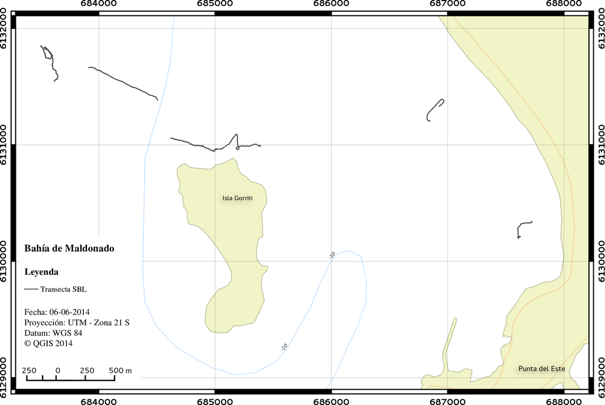

**Figura 1 –** Recorrido realizado con el Sonar de Barrido Lateral (SBL).

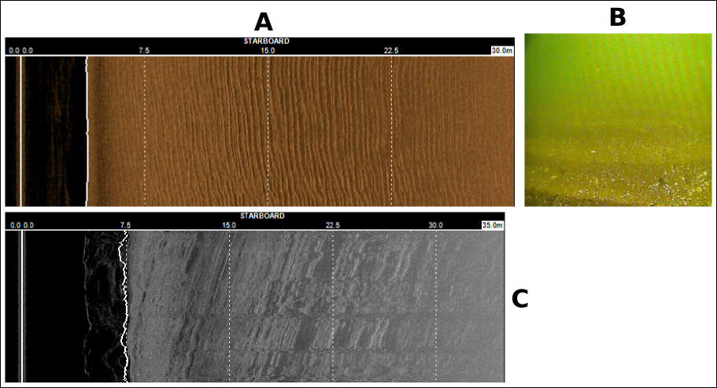

**Figura 2 –** Imagen de Sonar de Barrido Lateral (SBL) de un fondo marino arenoso con marcas de ripples y fotograma de filmación subacuática del mismo tipo de fondo (B). En C se muestra una imagen de SBL de un fondo marino rocoso.

#### Conclusiones:

La embarcación se mostro apta, versátil y con la seguridad necesaria para recibir al personal y equipamiento a ser utilizado para llevar adelante el trabajo. Los equipos científicos probados durante la salida funcionaron de forma correcta durante la toma de datos generada en la salida, sin embargo se detectaron una serie de dificultades a ser corregidas en próximas salidas. Estas se presentaron en la obtención de imágenes de alta calidad de forma continua con el SBL debido a la inestabilidad del equipo en las condiciones de corriente y viento presentes en la zona. Con el fin de mejorar el desempeño del mismo durante las próximas salidas se está trabajando en la adaptación de una estructura para su utilización como soporte del SBL. Con esta nueva estructura se pretende realizar una nueva salida de forma de evaluar su eficacia así como evaluar la existencia o no de interferencias entre el SBL y la ecosonda portátil BioSonics DT-X.

[figure not shown]

[output not shown]

[output not shown]